# Alphabet Soup

## A problem of decrypting encrypted words using Python | By Sian Thompson

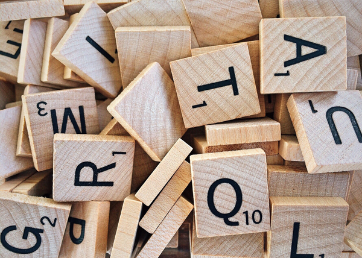

```python
from PIL import Image               # to load images
from IPython.display import display # to display images

basewidth = 600
pil_img = Image.open('assets/alphabet_soup.jpg')
wpercent = (basewidth/float(pil_img.size[0]))
hsize = int((float(pil_img.size[1])*float(wpercent)))
pil_img = pil_img.resize((basewidth,hsize), Image.ANTIALIAS)

display(pil_img)
```

## Here's the Alphabet Soup problem:

A list contains 10 common English words. However, they are incomplete. Zeros in each word represent where letters of the alphabet should substitute these. There are at least 26 zeros and each letter of the alphabet should be used exactly once to substitute the zeros and arrive at decrypted words.

The answers should be provided in a dictionary where encrypted words correspond to decrypted words.

Here's the encrypted list of words:

encrypted_words = ['0ri0t', '0ala00', '0e00est', '0e00ry', '0ra0e0', 's00r0', '00amy', '0ebr0', '0o0ey','0ro0ec0']

Here's the desired outcome as a dictionary:

answers_dict = {'0ri0t':'wrist', '0ala00': 'galaxy', '0e00est':'request', '0e00ry': 'celery',\'0ra0e0': 'braved', 's00r0':'shirk', '00amy':'foamy', '0ebr0': 'zebra', '0o0ey': 'money', '0ro0ec0': 'project'}

Now, I would like to point out, this challenge is not as simple as it looks. Please note the above python word challenge has taken inspiration from the following guardian article:

https://www.theguardian.com/science/2020/jul/13/can-you-solve-it-alphabet-soup

### Approaching the problem

An obvious issue with this problem is that if you substitute zeros to derive a 'test word', you would need to check whether the word is a potential English word which can be used. Also, producing a list of test words with all possible combinations with letters from the alphabet could take a long time if we were to consider a 'brute force' method.

Thus, I thought about how I can optimise fetching the most potential words for an encrypted word, based on varying the number of test words. Ultimately, I took on an approach that passes a test word to a NLP (Natural Language Processing) object and spellchecks the word to derive proxy words. In this process, the proxy words have to be checked to see whether are truly a potential word for the encrypted word.

### Using NLP libaries for spellchecking test words

I researched the following Python spellchecking libraries, which came with various strengths and weaknesses with regard to solving the problem:

[TextBlob](https://textblob.readthedocs.io/en/dev/)

- TextBlob is similar to the NLP Spacy library in that you can pass text such as a sentence to a NLP object in order to tag words e.g. as nouns etc.
- It references standing 'on the giant shoulders of NLTK and pattern'.
- What I discovered was that Textblob seemed to be more suitable than Spacy in evaluating individual words.

[Pyspellchecker](https://pypi.org/project/pyspellchecker/)

- Pyspellchecker provides some sophisticated spellschecking functionality.

### Creating code to find proxy words using TextBlob and Pyspellchecker

- In this section, we will evaluate the selection of proxy words derived from using the spellchecking libraries upon the encrypted and and decrypted words provided in the **answers_dict** dictionary.

```
from spellchecker import SpellChecker # Pyspellchecker
from textblob import Word as Textblob #Textblob
import pandas as pd

answers_dict = {'0ri0t':'wrist', '0ala00': 'galaxy', '0e00est':'request', '0e00ry': 'celery',
                '0ra0e0': 'braved', 's00r0':'shirk', '00amy':'foamy', '0ebr0': 'zebra',
                '0o0ey': 'money', '0ro0ec0': 'project'}

spell_checker = SpellChecker() #Pyspellchecker instance only has to be instantiated once

def get_text_blob_proxy_words(test_word):
    """
    Note the Textblob object has to be reinstantiated everytime you want
    to spellcheck a test word. Also textblob_proxy_words provides a list of tuples,
    e.g. [(foam, 0.8), (foams, 0.2)] for the test word foamy.
    Numbers provide a weighting of what a word may potentially be in a spellchecking
    scenario, rather than in this decryption scenario where we need to be mindful of
    the encrypyted word length. Thus the list comprehension below extracts the proxy
    words. Words with a weighting of 0 do not count as words and can be ignored. This
    particularly applies to the encrypted words which are returned in no proxy words
    are found e.g. [(s00r0, 0.0)]
    """
    textblob = Textblob(test_word)
    textblob_proxy_words = textblob.spellcheck()
    #return textblob_proxy_words
    return [k for k,v in textblob_proxy_words if v >0 ]


column_indexes = [v for v in answers_dict.values()] + [k for k in answers_dict.keys()]
pyspellchecker_proxy_words = [list(spell_checker.candidates(x)) for x in column_indexes]
# Note spell_checker.candidates(x) set is cast as a list for consistency

text_blob_proxy_words = [get_text_blob_proxy_words(x) for x in column_indexes]
```

```python
from spellchecker import SpellChecker # Pyspellchecker
from textblob import Word as Textblob #Textblob
import pandas as pd

answers_dict = {'0ri0t':'wrist', '0ala00': 'galaxy', '0e00est':'request', '0e00ry': 'celery',
                '0ra0e0': 'braved', 's00r0':'shirk', '00amy':'foamy', '0ebr0': 'zebra',
                '0o0ey': 'money', '0ro0ec0': 'project'}

spell_checker = SpellChecker() #Pyspellchecker instance only has to be instantiated once

def get_text_blob_proxy_words(test_word):
    """
    Note the Textblob object has to be reinstantiated everytime you want
    to spellcheck a test word.Also textblob_proxy_words provides a list of tuples,
    e.g. [(foam, 0.8), (foams, 0.2)] for the test word foamy.
    Numbers provide a weighting of what a word may potentially be in a spellchecking
    scenario, rather than in this decryption scenario where we need to be mindful of
    the encrypyted word length. Thus the list comprehension below extracts the proxy
    words. Words with a weighting of 0 do not count as words and can be ignored. This
    particularly applies to the encrypted words which are returned in no proxy words
    are found e.g. [(s00r0, 0.0)]
    """
    textblob = Textblob(test_word)
    textblob_proxy_words = textblob.spellcheck()
    #return textblob_proxy_words
    return [k for k,v in textblob_proxy_words if v >0 ]


column_indexes = [v for v in answers_dict.values()] + [k for k in answers_dict.keys()]
pyspellchecker_proxy_words = [list(spell_checker.candidates(x)) for x in column_indexes]
# Note spell_checker.candidates(x) set is cast as a list for consistency

text_blob_proxy_words = [get_text_blob_proxy_words(x) for x in column_indexes]
```

#### Pandas Dataframe with results for libaries

- Proxy words for each spellchecker are displayed in two separate columns in a pandas dataframe table. The encrypted and decrypted words are listed in the index column alongside.
- Essentially, this is to help gage how the libraries can be appropriately used to find proxy words.

```
df = pd.DataFrame({'TextBlob':text_blob_proxy_words,'Pyspellchecker':pyspellchecker_proxy_words},
                  index=column_indexes)
pd.set_option('display.max_column',None)
pd.set_option('display.max_rows',None)
pd.set_option('display.max_seq_items',None)
pd.set_option('display.max_colwidth', 500)
pd.set_option('expand_frame_repr', True)
df
```

```python
df = pd.DataFrame({'TextBlob':text_blob_proxy_words,'Pyspellchecker':pyspellchecker_proxy_words},
                  index=column_indexes)
pd.set_option('display.max_column',None)
pd.set_option('display.max_rows',None)
pd.set_option('display.max_seq_items',None)
pd.set_option('display.max_colwidth', 500)
pd.set_option('expand_frame_repr', True)
df
```

|  | TextBlob | Pyspellchecker |
| --- | --- | --- |
| wrist | [wrist] | [wrist] |
| galaxy | [galaxy] | [galaxy] |
| request | [request] | [request] |
| celery | [every, clerk, clergy, scenery, cheery, coley, celerity, belfry, eley, cutlery] | [celery] |
| braved | [braved] | [braved] |
| shirk | [shirt] | [shirk] |
| foamy | [foam, foams] | [foamy] |
| zebra | [vera, era, sera, zero, fera, zere, membra] | [zebra] |
| money | [money] | [money] |
| project | [project] | [project] |
| 0ri0t | [wrist, print, drift, writ, riot, rift, grit, grist] | [drift, britt, crit, wrist, grit, rift, print, writ, riot, pritt, trist, grist, brit, gritt] |
| 0ala00 | [] | [0ala00] |
| 0e00est | [] | [0e00est] |
| 0e00ry | [] | [0e00ry] |
| 0ra0e0 | [] | [0ra0e0] |
| s00r0 | [] | [s1000] |
| 00amy | [amy] | [foamy, loamy, lamy, amy, seamy] |
| 0ebr0 | [] | [zebra, debra, gebre, ebrd, ebro, debre] |
| 0o0ey | [money, obey, honey, coley, dovey] | [gooey, soley, dovey, joey, lovey, coley, okey, cowey, howey, posey, bogey, covey, tovey, nosey, holey, losey, fowey, toney, hoey, obey, jokey, povey, zoey, homey, odey, ropey, mobey, robey, boney, po… |
| 0ro0ec0 | [] | [0ro0ec0] |

**Disclaimer**

I'm not accountable for words suggested by the spellcheckers. No censorship is provided to provide a holistic picture on suggested words these provide for test words.

#### Evaluation of results from dataframe

Typically, both spellcheckers seem to return fewer words if there are more zeros present in the encrypted words.

**Textblob**

- The feature of providing weightings means that non-words can easily be excluded if they return 0 as explained within the function 'get_text_blob_proxy_words' above. In such cases, an empty list has been returned, particularly for encrypted words which include zeros.
- Looking at the decrypted words 'celery', 'foamy' and 'zebra', it would seem the Textblob corpus is incomplete as these words are not respectfully returned.

**Pyspellchecker**

- If there is only one result in the list, it would be necessary to check whether the proxy word contains zeros, so that non-words can be excluded.
- Seems to provide more proxy words, particularly for the encrypted words which is highly advantageous.
- However, testing other test words, this can be beyond the English language and can thus introduce noise.
- Ultimately, this means that there would be more potential words available for each letter of the alphabet, which may further distance ourselves from solving the problem

It's important to note that proxy words can only be considered as **potential words** if they are:

a) the same length of the encrypted word and b) retain the same letters at index positions which are not zero.

### Considerations in GitHub project

All these points have been considered for creating classes that find potential words, based on proxy words delivered from using the spellchecking libaries. These can be found here:

- TextBlobWordFinder
- PyspellcheckerWordFinder

Within my [GitHub project](https://github.com/Kremzeeq/alphabet_soup), word finder classes based on each of the spellchecking libaries, spellcheck test words, beyond the encrypted word passed to the instance. Test words are generated by substituting random letters at index positions for the zeros in the encrypyted word.

The [TextBlobWordFinder](https://github.com/Kremzeeq/alphabet_soup/blob/master/src/text_blob_word_finder.py) bypasses spellchecking the encrypted words directly, compared to the [PyspellcheckerWordFinder](https://github.com/Kremzeeq/alphabet_soup/blob/master/src/pyspellchecker_word_finder.py) in my project. However, as a consequence, there is a epoching process which takes time to accumulate a minimum number of required potential words. There are various parameters defined by the user. By contrast, the PyspellcheckerWordFinder only spellchecks a limited number of test words, because it is effective in obtaining proxy words directly from some of the encrypted words.

#### Building a Dictionary of Encrypted words with Potential words

With regard to each encrypted word, a dictionary is built with a list of potential words. This also includes a list of indexes for where zeros occur in the original encrypted word. Dictionaries for each encrypted word become nested within a a larger dictionary. This is referred to as a **potential_word_dict_collection** in my GitHub project. This example is built from using the TextBlobWordFinder:

{'0ri0t': {'potential_words_list': ['print', 'grist', 'wrist', 'drift'], 'zeros_list': [0, 3], 'success': True},  
'0ala00': {'potential_words_list': ['malady', 'balaga', 'galant', 'galaxy', 'falaba', 'palate', 'salary', 'palace'], 'zeros_list': [0, 4, 5], 'success': True}...  
'0ebr0': {'potential_words_list': [], 'zeros_list': [0, 4], 'success': False},  
'0ro0ec0': {'potential_words_list': ['project', 'protect'], 'zeros_list': [0, 3, 6], 'success': True}}

#### Building a Dictionary whereby Encrypted words are assigned to the alphabetical letters

The [PotentialWordTracker](https://github.com/Kremzeeq/alphabet_soup/blob/master/src/potential_word_tracker.py) helps build a **potential_words_by_alpha_dict** object which stores key words pairs for potential words and encrypted words by alphabetical order. As this is a large object to display, only a sample is provided below:

{'a': {'balaga': '0ala00', 'falaba': '0ala00', 'meanest': '0e00est', 'dearest': '0e00est', ...},  
'b': {'balaga': '0ala00', 'falaba': '0ala00', 'bequest': '0e00est', 'belfry': '0e00ry'...},  
'c': {'palace': '0ala00', 'descry': '0e00ry', 'traced': '0ra0e0', 'traces': '0ra0e0', ...}...  
'z': {'grazed': '0ra0e0', 'brazen': '0ra0e0'} }

#### Assigning Potential words to Encrypted words using a decoder

Assigning potential words to encrypted words demands a **process of assignment**. Considering the dictionary above, the [EncryptedWordDecoder](https://github.com/Kremzeeq/alphabet_soup/blob/master/src/encrypted_word_decoder.py) can be run to build a collection of decrypted word dictionaries. This is built over a series of epochs due to randomisation effects in the algorithm.

Remember, the final objective is to find optimal user-defined parameters, whereby as many 'correct' potential words can be assigned to the encrypted words, as per the answers_dict as possible.

In each decrypted word dictionary, a single potential word is assigned to each of the 10 encrypted words. Here's an example of a decrypted word dictionary:

{'00amy': 'liamy','0ala00': 'galaxy','0e00est': 'request','0e00ry': 'kefcry', '0ebr0': 'sebro','0o0ey': 'dovey','0ra0e0': 'brazen','0ri0t': 'hriet','0ro0ec0': 'project', 's00r0': 'swarm'}

Here's an overview of the **process of assignment** in a single epoch:

1. Get the starting letters: This is a list of letters where only one potential word has been assigned to a letter in the potential_words_by_alpha_dict parameter. If there are fewer than two starting letters, two random letters are chosen for this.
2. Usually, for each starting letter, a **decrypted word dictionary** is built where the single corresponding key value pair is the first to be assigned to the decrypted word dictionary. e.g. 'g' might only have { 'galaxy': '0ala00'}.
3. Progressively, letters are removed from a copy of the **potential_words_by_alpha_dict** as they may be included at zero index positions of the encrypted word which is added to the decrypted word dictionary. Nested pairs of encrypted word along with potential words are also removed.
4. The algorithm progressively assigns further encrypted words to the **decrypted word dictionary**, by prioritising those with the fewest key value pairs available in the **potential_words_by_alpha_dict**. This can involve some random selection.
5. The final stage finally randomly assigns unassigned letters to unassigned words. Not the perfect solution, but as highlighted above the spellcheckers are not perfect at identifying true words.

#### Evaluating results from changing user-defined parameters

The [Experimenter](https://github.com/Kremzeeq/alphabet_soup/blob/master/src/experimenter.py) in my project executes two distinct methods which correspond to using the word finder classes to obtain proxy words as separate prerequisites to running the **EncryptedWordDecoder**. Parameters which can be tweaked for each of these are listed for each respective method below.

- **get_results_for_text_blob_word_finder**
  - **max_epochs**: Maximum no. of epochs which are run with a minimum number of interations
  - **min_iters_per_epoch**: Minimum no. of iterations in an epoch. In each iteration, letters randomly substitute the zeros in the word to produce a test word.
  - **min_potential_words**: If the threshold of providing a minimum number of potential words is not satisfied following epoching, then another attempt is made to derive proxy words for the encrypted words.
  - **max_attempts**: Limits the number of attempts for epoching
- **get_results_for_pyspellchecker_word_finder**
  - **pyspellchecker_no_of_random_letters**: Should be in between 1 and 27. Represents no. of random letters which would be substituted into encrypted words at the first zero index position to produce test words

There is also a parameter which sets the maximum number of epochs which are run for the decoder.

The **Experimenter** can be run by executing the [src.main.py](https://github.com/Kremzeeq/alphabet_soup/blob/master/src/main.py) script. This assigns different values to each of the parameters above as part of stress tests. It integrates a [ReportMaker](https://github.com/Kremzeeq/alphabet_soup/blob/master/src/report_maker.py) which helps output parameters with results in a csv report: which can be downloaded here:

alphabet_soup_report.csv

The report has been produced by executing section 1 of the main script three times.

The results can be viewed in a pandas dataframe. Please note the no_of_runs corresponds to the number of decrypted word dictionaries that were collected in a stress test. This is typically twice the number of the maximum number of epochs run for the word decoder:

```
results_df = pd.read_csv("reports/alphabet_soup_report_fixed.csv")
results_df.head()
```

```python
results_df = pd.read_csv("reports/alphabet_soup_report_fixed.csv")
results_df.head()
```

|  | no_of_runs | mean_accuracy | standard_dev | median | word_decoder_max_epochs | word_finder_min_iters_per_epoch | word_finder_min_potential_words | word_finder_max_epochs | word_finder_max_attempts | no_of_random_letters | time_taken_in_seconds | word_finder_name | best_accuracy | best_decrypted_word_dict |
| --- | --- | --- | --- | --- | --- | --- | --- | --- | --- | --- | --- | --- | --- | --- |
| 0 | 150 | 28.866667 | 4.102163 | 30.0 | 75 | 50 | 5 | 3 | 3 | 0 | 438.690037 | TextBlobWordFinder | 40.0 | {'0ro0ec0': 'project', '0ala00': 'galaxy', '0e00est': 'request', '0ra0e0': 'brazen', '0o0ey': 'dovey', 's00r0': 'swarm', '0ebr0': 'kebre', '0ri0t': 'lriit', '00amy': 'foamy', '0e00ry': 'sechry'} |
| 1 | 150 | 28.733333 | 4.062708 | 30.0 | 75 | 50 | 5 | 3 | 3 | 0 | 382.826677 | TextBlobWordFinder | 40.0 | {'0ala00': 'galaxy', '0ro0ec0': 'project', '0ra0e0': 'brazen', '0e00est': 'request', '0o0ey': 'dovey', 's00r0': 'swarm', '0ebr0': 'kebre', '0ri0t': 'lriit', '00amy': 'foamy', '0e00ry': 'cehsry'} |
| 2 | 150 | 28.533333 | 4.394424 | 30.0 | 75 | 75 | 5 | 3 | 3 | 0 | 818.225044 | TextBlobWordFinder | 40.0 | {'0ro0ec0': 'project', '0ala00': 'galaxy', '0e00est': 'request', '0ra0e0': 'brazen', '0o0ey': 'dovey', 's00r0': 'swarm', '0ri0t': 'kriet', '00amy': 'foamy', '0ebr0': 'lebri', '0e00ry': 'hecsry'} |
| 3 | 150 | 27.800000 | 4.758602 | 30.0 | 75 | 100 | 5 | 3 | 3 | 0 | 835.377826 | TextBlobWordFinder | 40.0 | {'0ala00': 'galaxy', '0ro0ec0': 'project', '0e00est': 'request', '0ra0e0': 'brazen', '0o0ey': 'dovey', 's00r0': 'swarm', '0ri0t': 'hriit', '00amy': 'foamy', '0ebr0': 'sebre', '0e00ry': 'leckry'} |
| 4 | 150 | 28.266667 | 4.597441 | 30.0 | 75 | 125 | 5 | 3 | 3 | 0 | 1118.366127 | TextBlobWordFinder | 40.0 | {'0ala00': 'galaxy', '0ro0ec0': 'project', '0e00est': 'bequest', '0o0ey': 'money', 's00r0': 'shore', '0ri0t': 'wrist', '0ra0e0': 'draiea', '0e00ry': 'zekvry', '0ebr0': 'cebrf', '00amy': 'rlamy'} |

Below, we can see see what parameters provided the best accuracy (%) in at least a single run of a test. In realtion to this, we also need to be mindful of the mean_accuracy (%). This refers to the average percentage of encrypted words which were correctly decrypted for each run in a test, according to parameters presented in other columns.

```
max_best_accuracy = results_df.loc[results_df.reset_index().groupby(["word_finder_name"])\
                    ['best_accuracy'].idxmax()]

max_best_accuracy[['word_finder_name','no_of_runs','mean_accuracy','standard_dev','median',\
                   'word_decoder_max_epochs','word_finder_min_iters_per_epoch']]
```

```python
max_best_accuracy = results_df.loc[results_df.reset_index().groupby(["word_finder_name"])['best_accuracy'].idxmax()]

max_best_accuracy[['word_finder_name', 'no_of_runs','mean_accuracy','standard_dev','median','word_decoder_max_epochs','word_finder_min_iters_per_epoch']]
```

|  | word_finder_name | no_of_runs | mean_accuracy | standard_dev | median | word_decoder_max_epochs | word_finder_min_iters_per_epoch |
| --- | --- | --- | --- | --- | --- | --- | --- |
| 84 | PyspellcheckerWordFinder | 150 | 22.800000 | 13.266499 | 20.0 | 75 | 0 |
| 51 | TextBlobWordFinder | 150 | 32.866667 | 7.971145 | 30.0 | 75 | 50 |

```
max_best_accuracy[['word_finder_name','word_finder_min_potential_words','word_finder_max_epochs',\
                   'word_finder_max_attempts','no_of_random_letters','time_taken_in_seconds']]
```

```python
max_best_accuracy[['word_finder_name','word_finder_min_potential_words','word_finder_max_epochs','word_finder_max_attempts','no_of_random_letters','time_taken_in_seconds']]
```

|  | word_finder_name | word_finder_min_potential_words | word_finder_max_epochs | word_finder_max_attempts | no_of_random_letters | time_taken_in_seconds |
| --- | --- | --- | --- | --- | --- | --- |
| 84 | PyspellcheckerWordFinder | 0 | 0 | 0 | 25 | 186.050981 |
| 51 | TextBlobWordFinder | 5 | 3 | 3 | 0 | 343.765691 |

```
pd.set_option('display.max_column',None)
pd.set_option('display.max_rows',None)
pd.set_option('display.max_seq_items',None)
pd.set_option('display.max_colwidth', 500)
pd.set_option('expand_frame_repr', True)
max_best_accuracy[['word_finder_name','best_accuracy', 'best_decrypted_word_dict']]
```

```python
pd.set_option('display.max_column',None)
pd.set_option('display.max_rows',None)
pd.set_option('display.max_seq_items',None)
pd.set_option('display.max_colwidth', 500)
pd.set_option('expand_frame_repr', True)
max_best_accuracy[['word_finder_name','best_accuracy', 'best_decrypted_word_dict']]
```

|  | word_finder_name | best_accuracy | best_decrypted_word_dict |
| --- | --- | --- | --- |
| 84 | PyspellcheckerWordFinder | 70.0 | {'0o0ey': 'money', '0e00est': 'request', '0ala00': 'galaxy', '0ra0e0': 'tralee', '0ebr0': 'zebra', 's00r0': 'shirk', '0ri0t': 'wrist', '00amy': 'foamy', '0ro0ec0': 'jrobecv', '0e00ry': 'pecdry'} |
| 51 | TextBlobWordFinder | 50.0 | {'0ala00': 'galaxy', '0ro0ec0': 'project', '0ra0e0': 'brazen', '0e00est': 'request', '0o0ey': 'dovey', 's00r0': 'sacre', '0ri0t': 'wrist', '0ebr0': 'mebri', '00amy': 'foamy', '0e00ry': 'kehlry'} |

Ok, so this shows that best accuracy (70%) was achieved with:

- Word Finder: PyspellcheckerWordFinder
- word_decoder_max_epochs: 75 -> resulting in 150 runs
- no_of_random_letters: 25

However, it's important to check whether this is significantly different to other stress test results for the PyspellcheckerWordFinder. This is particularly as mean_accuracy appears to be significantly lower (22.8%) than the TextBlobFinder (32.8%). The TextBlobWordFinder also shows more favourable lower standard_dev.

Thus far, the PyspellcheckerWordFinder demonstrates a big time advantage:

- 186.1 seconds vs 343.8 seconds for the TextBlobWordFinder

To get a bigger picture on mean accuracy, the histogram below helps visualise that mean_accuracy was predominantly at around 30% for stress tests.

```
#imports for data visualisation libraries

import matplotlib.pyplot as plt
import seaborn as sns
%matplotlib inline

sns.distplot(results_df["mean_accuracy"])
```

```python
import matplotlib.pyplot as plt
import seaborn as sns
%matplotlib inline
```

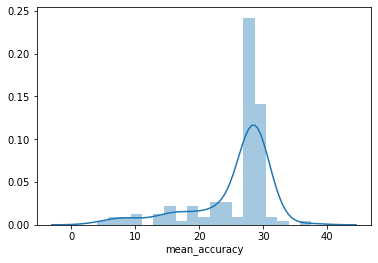

```python
sns.distplot(results_df["mean_accuracy"])
```

Deep diving into dataframe subsets for the word finders can help pinpoint their story in optimising mean_accuracy.

#### Investigating the Pyspellchecker word finder

Looking at the heatmap, here are some points to investigate:

1. Optimising for greater mean_accuracy leads to improved best_accuracy
2. Increasing the no_of_random_letters could lead to improvements for both accuracy measures
3. Increasing the no_of_random_letters is a trade off for time taken
4. There may a weak positive correlation between the no_of_runs and best_accuracy

```
pyspellchecker_df = results_df[results_df['word_finder_name']=="PyspellcheckerWordFinder"]
pyspellchecker_df = pyspellchecker_df[['no_of_runs','mean_accuracy', 'best_accuracy',\
                                       'no_of_random_letters', 'time_taken_in_seconds']]

sns.heatmap(pyspellchecker_df.corr(), cmap="BuPu")
```

```python
pyspellchecker_df = results_df[results_df['word_finder_name']=="PyspellcheckerWordFinder"]
pyspellchecker_df = pyspellchecker_df[['no_of_runs','mean_accuracy', 'best_accuracy', 'no_of_random_letters', 'time_taken_in_seconds']]
```

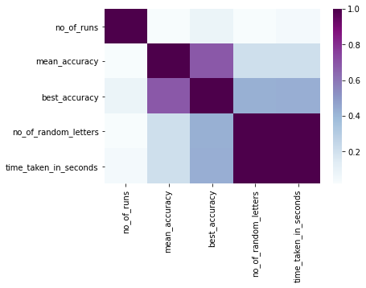

```python
sns.heatmap(pyspellchecker_df.corr(), cmap="BuPu")
```

**1. Optimising for greater mean_accuracy leads to improved best_accuracy**

- Regression plot shows this appears to be true
- Mean_accuracy of around 23% seems to have led to achieving the best_accuracy of at least 40%

```
sns.regplot(pyspellchecker_df['mean_accuracy'], pyspellchecker_df['best_accuracy'])
```

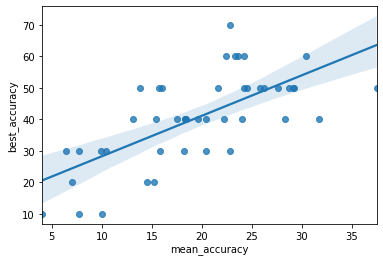

```python
sns.regplot(pyspellchecker_df['mean_accuracy'], pyspellchecker_df['best_accuracy'])
```

**2. Increasing the no_of_random_letters could lead to improvements for both accuracy measures**

- Yes, optimising no_of_letters e.g. so more alphabetical letters are considered for deriving proxy words appears to be associated with greater accuracy.
- However, it is good to acknowledge there are some tests which have only used around 8 no_of_random_letters to achieve mean accuracy of over 28%. This is likely to be due to random effects in the algorithm

```
sns.relplot(x='mean_accuracy', y='best_accuracy', size='no_of_random_letters',
            sizes=(40, 400), alpha=.5, palette="muted",height=6, data=pyspellchecker_df )
```

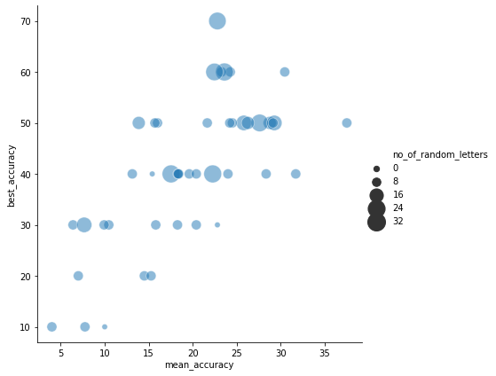

```python
sns.relplot(x='mean_accuracy', y='best_accuracy', size='no_of_random_letters',
            sizes=(40, 400), alpha=.5, palette="muted",height=6, data=pyspellchecker_df )
```

**3. Increasing the no_of_random_letters is a trade off for time taken**

- This is absoluetly true!!

```
sns.regplot(pyspellchecker_df['time_taken_in_seconds'], pyspellchecker_df['no_of_random_letters'])
```

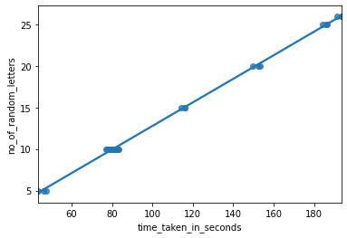

```python
sns.regplot(pyspellchecker_df['time_taken_in_seconds'], pyspellchecker_df['no_of_random_letters'])
```

**4. There may a weak positive correlation between the no_of_runs and best_accuracy**

- Looking at no_of_runs plotted against best_accuracy didn't really offer a story
- However, adding no_of_random_letters as a dimension helps provide some context
- Greatest best_accuracy seems to be associated with at least 150 runs. However, there are more data points for this, as part of scoping with the Experimenter class in the project.

```
sns.relplot(x='no_of_runs', y='best_accuracy', size='no_of_random_letters',
            sizes=(40, 400), alpha=.5, palette="muted",height=6, data=pyspellchecker_df )
```

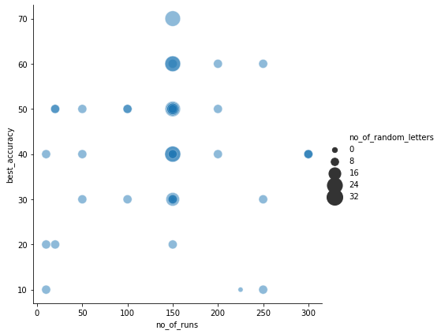

```python
sns.relplot(x='no_of_runs', y='best_accuracy', size='no_of_random_letters',
            sizes=(40, 400), alpha=.5, palette="muted",height=6, data=pyspellchecker_df )
```

**Conclusion on Optimising parameters for Pyspellchecker**

- As time isn't such a limitation with this word finder, it makes sense to run the word_finder with an optimal number of random letters at 26.
- Also, it would be helpful to obtain more tests for running this with a minimum of 150 runs to see if this impacts any further on improving accuracy.

#### Investigating the Textblob word finder

Looking at the heatmap, here are some points to investigate:

1. Optimising for greater mean_accuracy leads to improved best_accuracy
2. Increasing no_of_runs leads to improved accuracy measures
3. Increasing the number of word finder epochs is a detriment to time taken and has little or no impact on accuracy

```
textblob_df = results_df[results_df['word_finder_name']=="TextBlobWordFinder"]
textblob_df = textblob_df[['no_of_runs','mean_accuracy', 'best_accuracy','word_finder_min_potential_words',\
                           'word_finder_max_epochs','word_finder_max_attempts',
                           'time_taken_in_seconds']]

sns.heatmap(textblob_df.corr(), cmap="BuPu")
```

```python
textblob_df = results_df[results_df['word_finder_name']=="TextBlobWordFinder"]
textblob_df = textblob_df[['no_of_runs','mean_accuracy', 'best_accuracy', 'word_finder_min_potential_words','word_finder_max_epochs','word_finder_max_attempts', 'time_taken_in_seconds']]
```

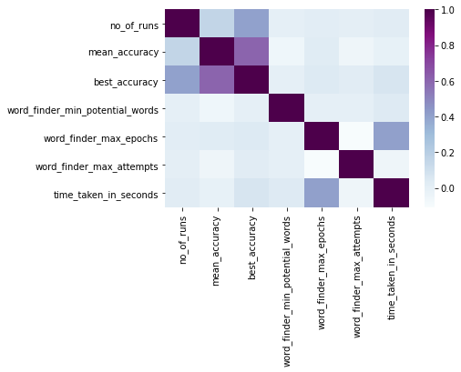

```python
sns.heatmap(textblob_df.corr(), cmap="BuPu")
```

**1. Optimising for greater mean_accuracy leads to improved best_accuracy**

- At first glance, there is a strong positive correlation, however, it appears at least 90% of datapoints achieve best_accuracy of 40%, with variable mean_accuracy between 27% and 31%.
- There are some key outliers which are polarised in achieving best_accuracy of 30% and close to 50%, impacting the gradient.
- Rather than exclude these points from analysis, it's good to investigate why these points may be so different.

```
sns.regplot(textblob_df['mean_accuracy'], textblob_df['best_accuracy'])
```

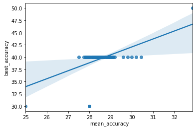

```python
sns.regplot(textblob_df['mean_accuracy'], textblob_df['best_accuracy'])
```

**2. Increasing no_of_runs leads to improved accuracy measures**

- Bubble plot suggests that by setting a parameter of at least 100 runs, there is a chance of achieving best_accuracy of 50%.
- However, in the grand scheme of things, this translates to setting parameters so there is a chance of getting just one more word of the ten total words correctly decrypted compared to the vast majority of data points.

```
sns.relplot(x='mean_accuracy', y='best_accuracy', size='no_of_runs',
            sizes=(40, 400), alpha=.5, palette="muted",height=6, data=textblob_df )
```

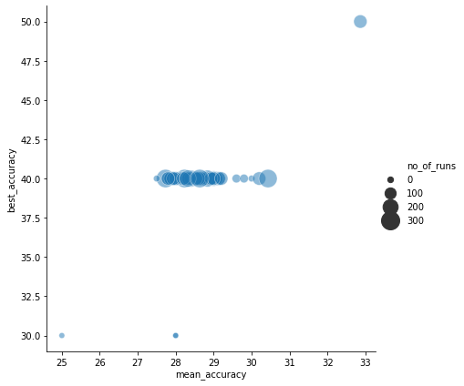

```python
sns.relplot(x='mean_accuracy', y='best_accuracy', size='no_of_runs',
            sizes=(40, 400), alpha=.5, palette="muted",height=6, data=textblob_df )
```

**3. Increasing the number of word finder epochs is a detriment to time taken and has little or no impact on accuracy**

- Bubble plot shows word_finder_max_epochs was set to 3 for most datapoints and mean_accuracy for these points is not significantly different to those with a set greater number of epochs.

```
sns.relplot(x='word_finder_max_epochs', y='time_taken_in_seconds', size='mean_accuracy',
            sizes=(40, 400), alpha=.5, palette="muted",height=6, data=textblob_df )
```

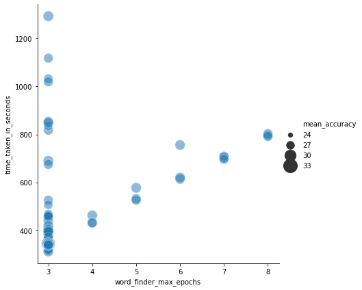

```python
sns.relplot(x='word_finder_max_epochs', y='time_taken_in_seconds', size='mean_accuracy',
            sizes=(40, 400), alpha=.5, palette="muted",height=6, data=textblob_df )
```

**Conclusion on Optimising parameters for Textblob**

- No more than 3 word_finder_max_epochs are required for achieving mean_accuracy of at least 27%, with at least 100 runs
- This seems to be a reliable formula for achieving best_accuracy of 40% for most cases

## Summary of Project

Overall, accuracy measures are not entirely dependent on the word finders. However, their role is key to finding potential words for encrypted words. The **EncryptedWordDecoder** introduces further randomness in the way in which words may be assigned to encrypted words. As one idea, the algorithm could be improved to spell check words when unassigned letters are assigned to unassigned words. Whilst this may prolong the time that the algorithm takes to run, greater mean accuracy could be expected. But, it's important to note the success rate of this would be determined by the scope of the spellchecker corpus and capabilities as has been discussed. Thus, further research could take place into alternative spellcheckers.

Next steps for this project could be to train a machine learning algorithm to find decrypted words based on encrypted words. This project only considered one use case, presented in the **answers_dict**, but a training set could be developed with further words to decrypt. This shouldn't overlook that each zero can only be substituted once by each respective letter of the alphabet in each use case.

**Thanks for reading! If you made it this far, hat off to you :)**

```python
%%html
<style>
div.input {
    display:none;
}

</style>
```